# Educational Data Mining Class Project

Dan Lim

11-22-2016

## 1. Introduction

- **objective**: apply algorithm described in reference paper to public students performance data
- **dataset url**: https://archive.ics.uci.edu/ml/datasets/Educational+Process+Mining+(EPM)%3A+A+Learning+Analytics+Data+Set
- **reference paper**: Anticipating student’s failure as soon as possible
- **source code**: https://github.com/imdanboy/edm_class_project

required library

```r
library(readxl) # read excel file
library(dplyr) # data manipulation
library(tidyr) # ""
library(caret) # machine learning
library(RWeka) # C4.5 Algorithm
library(arules) # association rules
library(ggplot2) # visualization
library(stringr) # string manipulation
```

## 2. Exploratory Data Analysis

first 10 rows of preprocessed dataset

```
## # A tibble: 115 × 5
##     Exam1  Exam2  Exam3  Exam4 `Final Grade`
##    <fctr> <fctr> <fctr> <fctr>        <fctr>
## 1       A      F      B      A             A
## 2       B      A      B      A             A
## 3       B      A      B      A             A
## 4       A      A      A      B             A
## 5       A      A      A      A             A
## 6       A      A      B      C             A
## 7       B      A      B      A             A
## 8       B      A      C      C             F
## 9       C      B      C      A             A
## 10      A      A      B      A             A
## # ... with 105 more rows
```

I divide the exam score into the grade as following criteria

| Grade | Percentage |
| --- | --- |
| A | > 75% |
| B | > 50% |
| C | > 25% |
| F | ~ 25% |

**Note**: Final Grade was eqaully distributed A, B, C, F; since it is binary classification problem predicting students failure; A,B,C is converted to A which stand for ‘Approved’ and F as it is, meaning ‘Failure’.

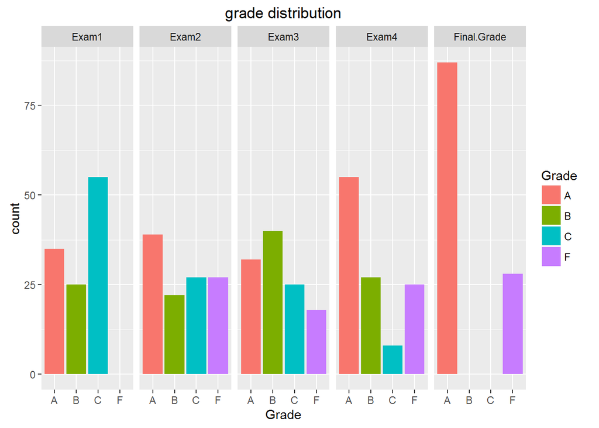

## 3. Baseline Model [Optimistic vs Pessimistic]

- I train [C4.5](https://en.wikipedia.org/wiki/C4.5_algorithm) with repeated cross validation(7 folds, 4 repeats).
- Optimistic is trained on dataset with Exam1, Exam2, Exam3, Exam4 as predictor.
- Pessimistic is trained on dataset with EXam1, Exam2 as predictor.

### Optimistic Classifier

```
## C4.5-like Trees
##
## 115 samples
##   4 predictor
##   2 classes: 'F', 'A'
##
## No pre-processing
## Resampling: Cross-Validated (7 fold, repeated 4 times)
## Summary of sample sizes: 99, 98, 98, 98, 99, 99, ...
## Resampling results:
##
##   logLoss   ROC        Accuracy   Kappa      Sensitivity  Specificity
##   1.911181  0.7892628  0.8588498  0.5672864  0.6071429    0.9400183
##   Pos_Pred_Value  Neg_Pred_Value  Detection_Rate  Balanced_Accuracy
##   0.8074074       0.8879107       0.1479779       0.7735806
##
## Tuning parameter 'C' was held constant at a value of 0.25
##
```

### Pessimistic Classifier

```
## C4.5-like Trees
##
## 115 samples
##   2 predictor
##   2 classes: 'F', 'A'
##
## No pre-processing
## Resampling: Cross-Validated (7 fold, repeated 4 times)
## Summary of sample sizes: 99, 98, 98, 98, 99, 99, ...
## Resampling results:
##
##   logLoss   ROC        Accuracy   Kappa       Sensitivity  Specificity
##   0.542172  0.6088599  0.7389706  0.09434208  0.1607143    0.9255952
##   Pos_Pred_Value  Neg_Pred_Value  Detection_Rate  Balanced_Accuracy
##   0.4010417       0.7758646       0.03899685      0.5431548
##
## Tuning parameter 'C' was held constant at a value of 0.25
##
```

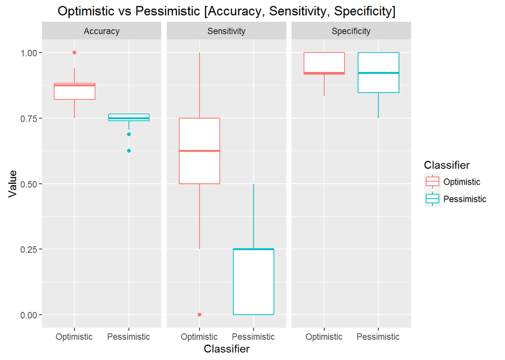

## 4. CAR ASAP

##### **C**lass **A**ssociation **R**ule based **A**s **S**oon **A**s **P**ossible classifier

simple example when association mining algorithm applied to dataset

```
##    lhs                  rhs             support   confidence lift
## 1  {Exam4=F}         => {Exam1=C}       0.1739130 0.8000000  1.6727273
## 2  {Exam1=B}         => {Final Grade=A} 0.1913043 0.8800000  1.1632184
## 3  {Exam2=C}         => {Exam1=C}       0.1652174 0.7037037  1.4713805
## 4  {Exam4=B}         => {Final Grade=A} 0.1652174 0.7037037  0.9301831
## 5  {Exam2=F}         => {Exam1=C}       0.1826087 0.7777778  1.6262626
## 6  {Final Grade=F}   => {Exam1=C}       0.2000000 0.8214286  1.7175325
## 7  {Exam3=A}         => {Exam4=A}       0.2347826 0.8437500  1.7642045
## 8  {Exam3=A}         => {Final Grade=A} 0.2782609 1.0000000  1.3218391
## 9  {Exam1=A}         => {Final Grade=A} 0.2869565 0.9428571  1.2463054
## 10 {Exam2=A}         => {Exam4=A}       0.2608696 0.7692308  1.6083916
## 11 {Exam2=A}         => {Final Grade=A} 0.3304348 0.9743590  1.2879458
## 12 {Exam3=B}         => {Final Grade=A} 0.3130435 0.9000000  1.1896552
## 13 {Exam4=A}         => {Final Grade=A} 0.4695652 0.9818182  1.2978056
## 14 {Exam1=A,Exam3=A} => {Final Grade=A} 0.1652174 1.0000000  1.3218391
## 15 {Exam2=A,Exam3=A} => {Exam4=A}       0.1565217 0.8571429  1.7922078
## 16 {Exam2=A,Exam3=A} => {Final Grade=A} 0.1826087 1.0000000  1.3218391
## 17 {Exam3=A,Exam4=A} => {Final Grade=A} 0.2347826 1.0000000  1.3218391
```

#### How to find the best association rule to fill in missing attributes

I choose the rule in this priority

1. more specific rule, in my R code `n_attr` should be higher ex) {Exam1=A, Exam2=B} => {Exam3=B} is better than {Exam1=A} => {Exam3=B}
2. higher accuracy
3. higher support
4. higher confidence
5. if rule doesn’t exist, just choose mode value in that column

### Performance Results

I trained ‘car asap classifier’ in same enviroment as baseline model, i.e., same seed, C4.5 algorithm, repeated cross validation 7 folds, 4 repeats

**Note**: sensitivity reports how well classifier could predict students failure.

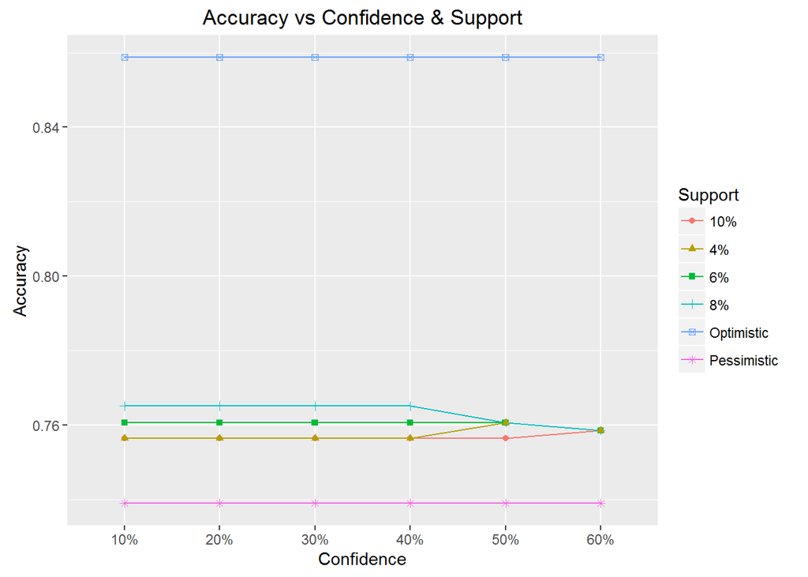

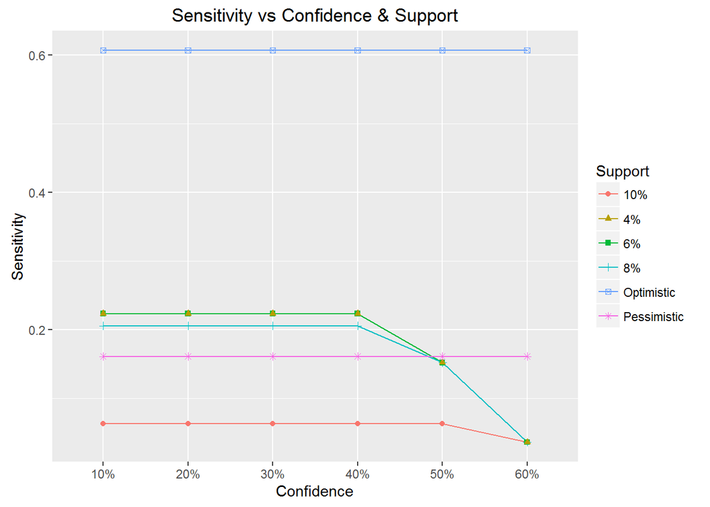

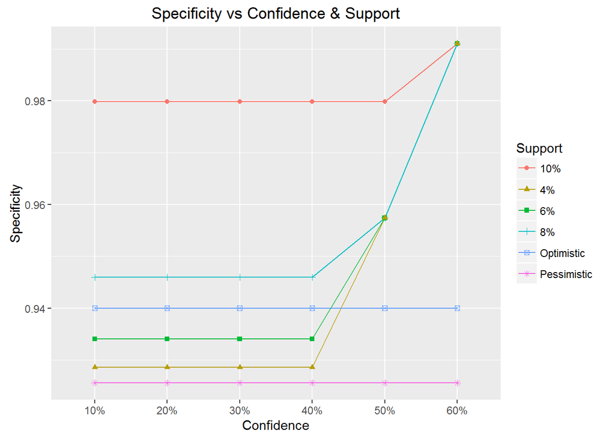

### t-test on accuracy

car asap (support = 0.08, confidence = 0.1, accuracy = 0.5) vs. pessimistic

```
##
##  Welch Two Sample t-test
##
## data:  asap.for.t.test$accuracy and pessimistic$resample$Accuracy
## t = 2.463, df = 49.392, p-value = 0.008654
## alternative hypothesis: true difference in means is greater than 0
## 95 percent confidence interval:
##  0.008346108         Inf
## sample estimates:
## mean of x mean of y
## 0.7650998 0.7389706
```